# agriRank in practice

From the experimental design to the publishable figure: an integrated tutorial

Author

Walter Esfrain Pereira

Published

August 15, 2026

```r
suppressPackageStartupMessages(library(agriRank))
packageVersion("agriRank")
```

```
#> [1] '0.13.0'
```

# 1 Introduction

**NoteWhat is agriRank?**

`agriRank` is an R package for **design-aware statistical inference** in agricultural experiments. It represents the randomization structure explicitly (CRD, RCBD, factorial, split-plot, repeated measures, and more) and connects that declaration to rank-based, permutation, relative-effect and resampling analyses: it never replaces the design with an analysis of “independent” observations when they are not.

**ImportantThe golden rule of the package**

**The design is declared before the data are analysed.** agriRank silently refuses any route that discards the randomization structure. For example: Kruskal-Wallis is not applied to an RCBD, because the blocks would disappear from the analysis. That is the difference between “running a test” and “making inference about the experiment that was actually conducted”.

This tutorial walks through four scientific questions typical of agricultural experimentation:

1. **Qualitative factor** (cultivars, management systems): CRD, RCBD, factorial and split-plot designs, with ANOVA-like analysis, multiple comparisons with letters (CLD) and figures;
2. **Quantitative factor** (dose, salinity, irrigation depth): nonparametric regression, with fit, figures with uncertainty, derivative and optimum;
3. **Qualitative + quantitative** (dose by cultivar): levels of the qualitative factor compared with confidence intervals;
4. **Integer ordinal factor** (plants per hill, number of irrigations): all integer models, optimum and decisions.

All data are generated by `simulate_agri()`, which reproduces realistic agronomic scenarios with a fixed seed: the whole tutorial is reproducible.

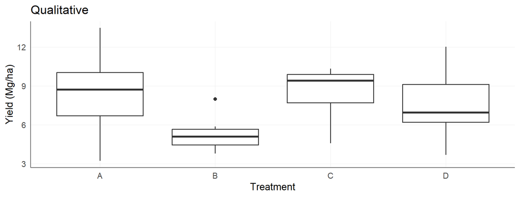

Three types of experimental factor: qualitative (cultivars), continuous quantitative (N dose) and integer ordinal (plants per hill).

```r
qual <- simulate_agri("crd", seed = 1)
quant <- simulate_agri("dose_response", seed = 1, n = 6)
inteiro <- simulate_agri("integer_density", seed = 1, n = 4)

ggplot2::ggplot(qual, ggplot2::aes(treatment, yield)) +
  ggplot2::geom_boxplot() + ggplot2::labs(x = "Treatment", y = "Yield (Mg/ha)") +
  ggplot2::ggtitle("Qualitative") + agri_theme()
```

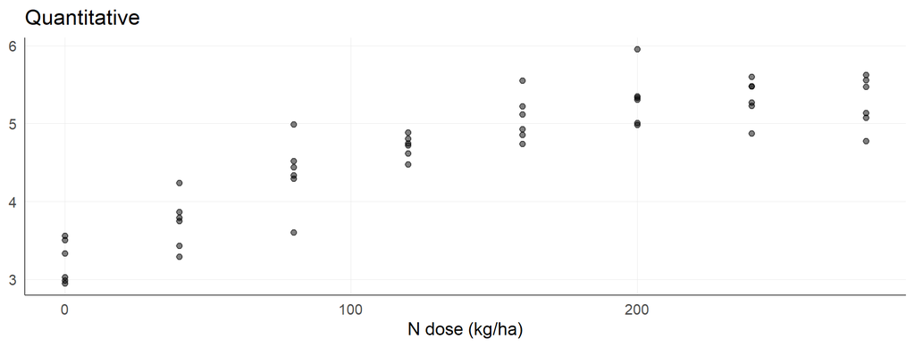

Three types of experimental factor: qualitative (cultivars), continuous quantitative (N dose) and integer ordinal (plants per hill).

```r
ggplot2::ggplot(quant, ggplot2::aes(dose, yield)) +
  ggplot2::geom_point(alpha = .5) + ggplot2::labs(x = "N dose (kg/ha)", y = NULL) +
  ggplot2::ggtitle("Quantitative") + agri_theme()
```

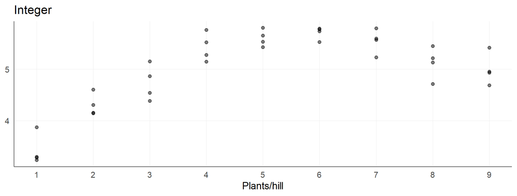

Three types of experimental factor: qualitative (cultivars), continuous quantitative (N dose) and integer ordinal (plants per hill).

```r
ggplot2::ggplot(inteiro, ggplot2::aes(plants, yield)) +
  ggplot2::geom_point(alpha = .5) +
  ggplot2::scale_x_continuous(breaks = unique(inteiro$plants)) +
  ggplot2::labs(x = "Plants/hill", y = NULL) +
  ggplot2::ggtitle("Integer") + agri_theme()
```

**TipStudy tip**

Before any analysis, **look at the data**. The figures above already answer three questions: do the groups separate? does the response rise and then stabilize? is there an intermediate peak? Statistics will quantify what the eye suggests, and not replace the eye.

# 2 Part I: Qualitative factors

A qualitative factor has **levels without intrinsic order**: cultivars, genotypes, management systems. The question is “do the levels differ?” and then “which differ from which?”. agriRank answers with design-aware rank tests and multiple comparisons with letters.

**ImportantWhy nonparametric?**

Agricultural production data are typically **positive, right-skewed, and with variance that grows with the mean**: the simulated data in this tutorial come from gamma and log-normal distributions precisely for that reason. Under these conditions:

- the classical F test relies on normality and homogeneity of variance, which rarely hold;
- **rank-based** tests use only the order of the observations: they are invariant to monotone transformations, robust to extreme values, and do not depend on the shape of the distribution;
- the tested hypothesis (relative effect / stochastic separation) is directly interpretable in the field: “which cultivar tends to produce more?”.

The figure below shows the skewness of the simulated data: compare it with the bell shape that classical ANOVA would assume.

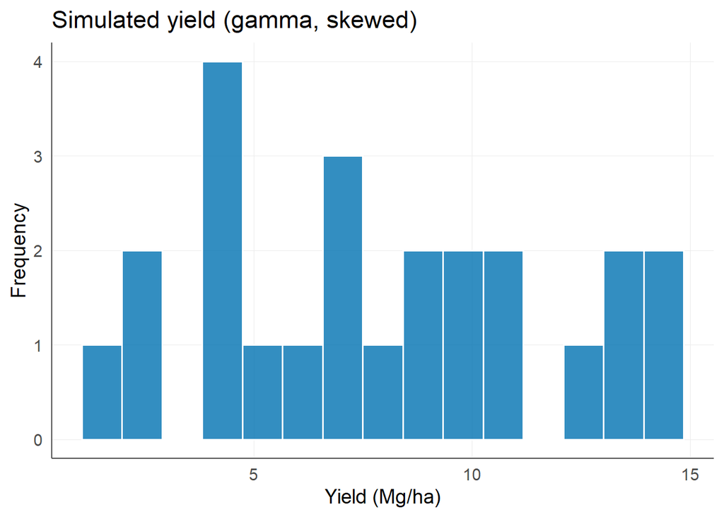

Typical skewness of yield data: positive values with a long right tail.

```r
d_skew <- simulate_agri("crd", seed = 40)
ggplot2::ggplot(d_skew, ggplot2::aes(yield)) +
  ggplot2::geom_histogram(bins = 15, fill = "#0072B2", alpha = .8, colour = "white") +
  ggplot2::labs(x = "Yield (Mg/ha)", y = "Frequency") +
  ggplot2::ggtitle("Simulated yield (gamma, skewed)") + agri_theme()
```

## 2.1 I.1 Completely randomized design (CRD)

**Agronomic question:** do four bean cultivars differ in grain yield, when each plot receives a cultivar drawn at random?

```r
d1 <- simulate_agri("crd", seed = 40)   # seed with real effects: the letters will differ
levels(d1$treatment) <- c("Ana", "Bela", "Cida", "Dora")   # cultivar names
head(d1, 8)
```

```
#>   treatment     yield
#> 1       Ana  6.624861
#> 2       Ana  6.692167
#> 3       Ana  2.651198
#> 4       Ana  5.752858
#> 5       Ana  2.179397
#> 6       Ana  1.515177
#> 7      Bela  8.946186
#> 8      Bela 14.232372
```

```r
des1 <- agri_design(yield ~ treatment, d1, design = "crd")
design_summary(des1)
```

```
#> $design
#> [1] "crd"
#>
#> $responses
#> [1] "yield"
#>
#> $treatments
#> [1] "treatment"
#>
#> $blocks
#> NULL
#>
#> $subjects
#> NULL
#>
#> $within
#> NULL
#>
#> $whole_plot
#> NULL
#>
#> $subplot
#> NULL
#>
#> $subsubplot
#> NULL
#>
#> $strip_a
#> NULL
#>
#> $strip_b
#> NULL
#>
#> $environment
#> NULL
#>
#> $n_rows
#> [1] 24
#>
#> $n_treatment_cells_observed
#> [1] 4
#>
#> $missing_response
#> yield
#>     0
#>
#> $randomization
#> [1] "Treatment assignments are exchangeable across experimental units, subject to the declared treatment structure."
#>
#> $validation
#> $ok
#> [1] TRUE
#>
#> $problems
#> [1] severity code     message
#> <0 linhas> (ou row.names de comprimento 0)
#>
#> attr(,"class")
#> [1] "agri_validation"
```

**NoteKey concept: what is declared**

`agri_design()` records the formula, the design and the randomization structure. In a CRD, treatments are **exchangeable across experimental units**: there is no restriction on the draw. Every later analysis inherits this declaration.

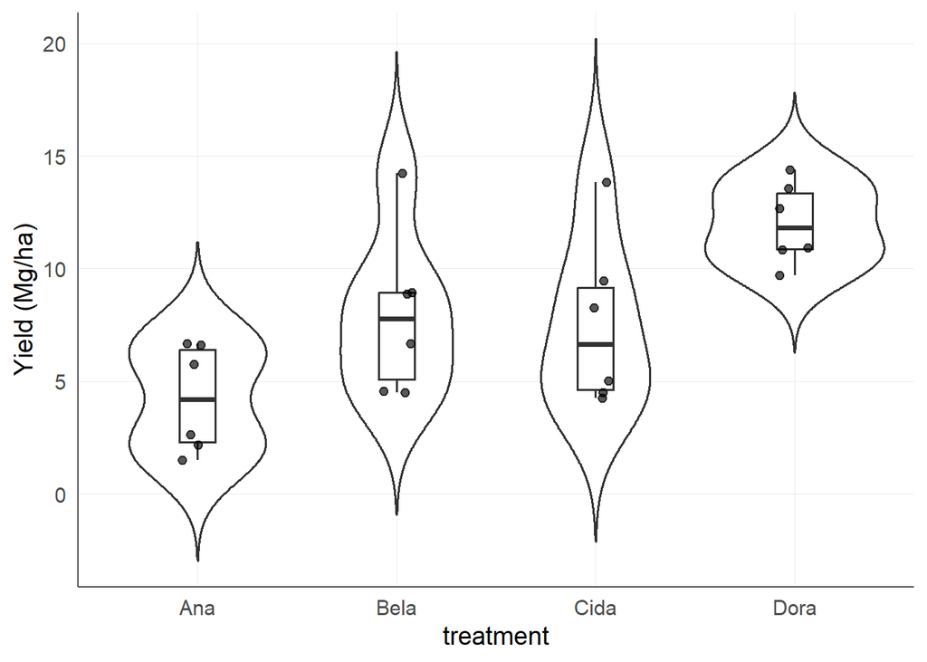

CRD data: distribution of yield by cultivar.

```r
agri_plot(des1, type = "data") + ggplot2::labs(y = "Yield (Mg/ha)") + agri_theme()
```

### 2.1.1 Analysis

```r
fit1 <- agri_rank(des1, method = "auto")   # auto: one factor, no block -> Kruskal-Wallis
fit1
```

```
#> agriRank fit
#>   Design: crd
#>   Method: Kruskal-Wallis
#>   Response: yield
#>      effect statistic df     p_value
#> 1 treatment  11.38667  3 0.009808642
```

```r
agri_table(fit1, "omnibus", format = "data.frame")
```

```
#>      effect statistic df     p_value
#> 1 treatment  11.38667  3 0.009808642
```

**TipHow to read the omnibus table**

The table reports the test statistic, the degrees of freedom and the **p-value of the global test**. A small p-value says “there is a difference somewhere”, but not where. The next step locates the difference.

### 2.1.2 Relative effects with interval

```r
agri_effects(fit1, ci = TRUE, B = 1000, seed = 41)
```

```
#>   cell n    median mean_rank
#> 1  Ana 6  4.202028  6.166667
#> 2 Bela 6  7.780358 12.500000
#> 3 Cida 6  6.639692 11.500000
#> 4 Dora 6 11.811015 19.833333
```

### 2.1.3 Multiple comparisons with letters (CLD)

```r
cc1 <- agri_conover(fit1, cld = TRUE, adjust = "holm")
cc1
```

```
#>   stratum group1 group2 paired_by_block  statistic      p_value  p_adjusted
#> 1     all   Bela    Ana           FALSE  2.0358441 0.0552297730 0.165689319
#> 2     all   Cida    Ana           FALSE  1.7143951 0.1019123255 0.203824651
#> 3     all   Cida   Bela           FALSE -0.3214491 0.7512053075 0.751205308
#> 4     all   Dora    Ana           FALSE  4.3931373 0.0002806772 0.001684063
#> 5     all   Dora   Bela           FALSE  2.3572932 0.0287098273 0.114839309
#> 6     all   Dora   Cida           FALSE  2.6787423 0.0144332607 0.072166304
#>                                         method
#> 1 Conover all-pairs after Kruskal-type ranking
#> 2 Conover all-pairs after Kruskal-type ranking
#> 3 Conover all-pairs after Kruskal-type ranking
#> 4 Conover all-pairs after Kruskal-type ranking
#> 5 Conover all-pairs after Kruskal-type ranking
#> 6 Conover all-pairs after Kruskal-type ranking
```

```r
agri_cld(cc1)
```

```
#>   group letter
#> 1  Bela     ab
#> 2  Cida     ab
#> 3  Dora      a
#> 4   Ana      b
```

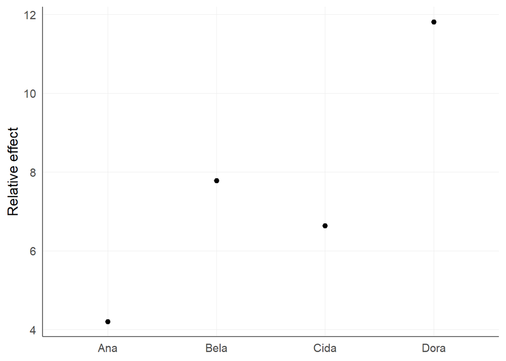

```r
agri_plot(fit1, type = "effects") + ggplot2::labs(y = "Relative effect") + agri_theme()
```

**WarningCommon mistake**

Equal letters mean “there was no evidence of a difference **at 5%**”, not “the means are identical”. Moreover, letters only compare treatments **within the same stratum**: never compare letters across strata.

## 2.2 I.2 Randomized complete block design (RCBD)

**Agronomic question:** the same four cultivars, now in a field with a fertility gradient. Each block contains every cultivar exactly once: the draw is restricted within the block.

```r
d2 <- simulate_agri("rcbd", seed = 2, n = 6)
levels(d2$treatment) <- c("Ana", "Bela", "Cida", "Dora")
des2 <- agri_design(yield ~ treatment, d2, design = "rcbd", block = block)
fit2 <- agri_rank(des2, method = "auto")   # auto: one factor + block -> Friedman
fit2
```

```
#> agriRank fit
#>   Design: rcbd
#>   Method: Friedman rank-sum
#>   Response: yield
#>      effect statistic df     p_value
#> 1 treatment        12  3 0.007383161
```

**ImportantWhy not Kruskal-Wallis?**

Applying Kruskal-Wallis here would treat the plots as independent and **throw away the block information**. agriRank blocks that route: with a declared block, the automatic method selects Friedman (ranks within blocks). The randomization structure of the experiment is part of the inference.

```r
cc2 <- agri_conover(fit2, cld = TRUE, adjust = "holm")
agri_cld(cc2)
```

```
#>   group letter
#> 1  Bela      a
#> 2  Cida     ab
#> 3  Dora      b
#> 4   Ana      a
```

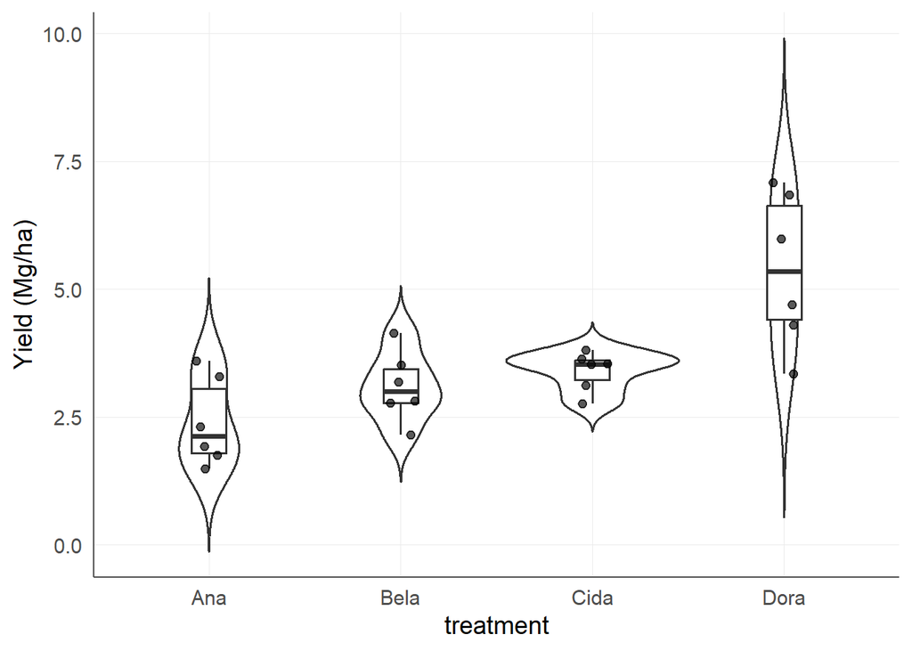

RCBD data: distribution by cultivar, with blocks present in the analysis.

```r
agri_plot(fit2, type = "data") + ggplot2::labs(y = "Yield (Mg/ha)") + agri_theme()
```

## 2.3 I.3 Factorial: two factors and the interaction

**Agronomic question:** two genotypes under three nitrogen fertilization levels. Is the fertilization gain the same for both genotypes, or is there an **interaction**?

```r
d3 <- simulate_agri("factorial", seed = 54, n = 6)   # seed with a real G x N interaction
levels(d3$A) <- c("G1", "G2"); levels(d3$B) <- c("N1", "N2", "N3")
des3 <- agri_design(yield ~ A * B, d3, design = "factorial")
fit3 <- agri_rank(des3, method = "auto")   # auto: two factors, no block -> rankFD
fit3
```

```
#> agriRank fit
#>   Design: factorial
#>   Method: rankFD pseudo-rank factorial inference
#>   Response: yield
#>   effect statistic    df1     df2 p_value
#> 1      A    6.3871 1.0000 22.9008  0.0189
#> 2      B    1.7562 1.8216 22.9008  0.1969
#> 3    A:B    5.6844 1.8216 22.9008  0.0116
```

```r
agri_table(fit3, "omnibus", format = "data.frame")
```

```
#>   effect statistic    df1     df2 p_value
#> 1      A    6.3871 1.0000 22.9008  0.0189
#> 2      B    1.7562 1.8216 22.9008  0.1969
#> 3    A:B    5.6844 1.8216 22.9008  0.0116
```

**NoteKey concept: interaction**

The G x N interaction asks whether the **effect of one factor depends on the level of the other**. In the data above it is significant (p = 0.012): the genotype effect changes with fertilization. When that happens, comparing marginal means (genotypes ignoring fertilization) can hide the real response. The correct route is the **simple effects** (the split by levels).

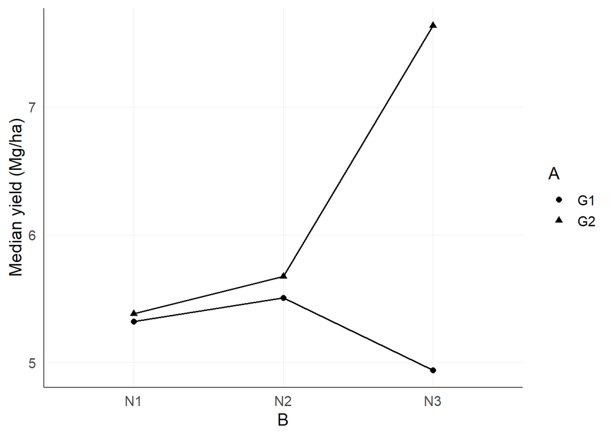

Interaction plot: median by genotype x fertilization combination.

```r
agri_plot(fit3, type = "interaction") +
  ggplot2::labs(y = "Median yield (Mg/ha)") + agri_theme()
```

### 2.3.1 Simple effects with letters within each stratum

```r
pr3 <- agri_pairs(fit3, by = "B", cld = TRUE, adjust = "holm")  # compare genotypes within each fertilization
agri_cld(pr3)
```

```
#>   stratum group letter
#> 1      N1    G1      a
#> 2      N1    G2      a
#> 3      N2    G1      a
#> 4      N2    G2      a
#> 5      N3    G1      a
#> 6      N3    G2      b
```

**TipHow to read the simple effects**

The letters **differ only within N3** (G1 = a, G2 = b): the genotype difference appears only at the highest fertilization. In N1 and N2 there is no evidence of difference. It is exactly this reading (an effect that depends on the level of the other factor) that defines the interaction in practice.

**WarningCommon mistake**

In the simple effects, the letters are computed **within each fertilization level**. Genotype G1 in N1 was never compared with G2 in N2, so the letters do not cross strata. agriRank computes the CLD per stratum precisely to prevent that reading.

## 2.4 I.4 Split-plot

**Agronomic question:** the response of three cultivars to irrigation (low/high): irrigation is drawn at the **whole-plot** level and cultivar at the **subplot** level, because it is easier to irrigate strips than isolated plots.

```r
d4 <- simulate_agri("split_plot", seed = 18, n = 8)   # seed with real irrigation and cultivar effects
des4 <- agri_design(yield ~ irrigation * cultivar, d4, design = "split_plot",
                    block = block, whole_plot = irrigation, subplot = cultivar)
fit4 <- agri_rank(des4, method = "ART")   # Aligned Rank Transform
agri_table(fit4, "omnibus", format = "data.frame")
```

```
#>                  Term          F Df Df.res      Pr(>F)              effect
#> 1          irrigation 17.7199536  1      7 0.003988183          irrigation
#> 2            cultivar  3.8159682  2     28 0.034234226            cultivar
#> 3 irrigation:cultivar  0.7791388  2     28 0.468494735 irrigation:cultivar
```

**NoteKey concept: two experimental errors**

A split-plot has **two randomization structures**: the whole-plot one (irrigation) and the subplot one (cultivar). Testing everything with a single error would inflate the whole-plot test. ART transforms ranks per stratum and respects the hierarchy of the design. In the table above, irrigation (p = 0.004) and cultivar (p = 0.034) are significant and the interaction is not: the effect is additive, and the figure shows roughly parallel lines.

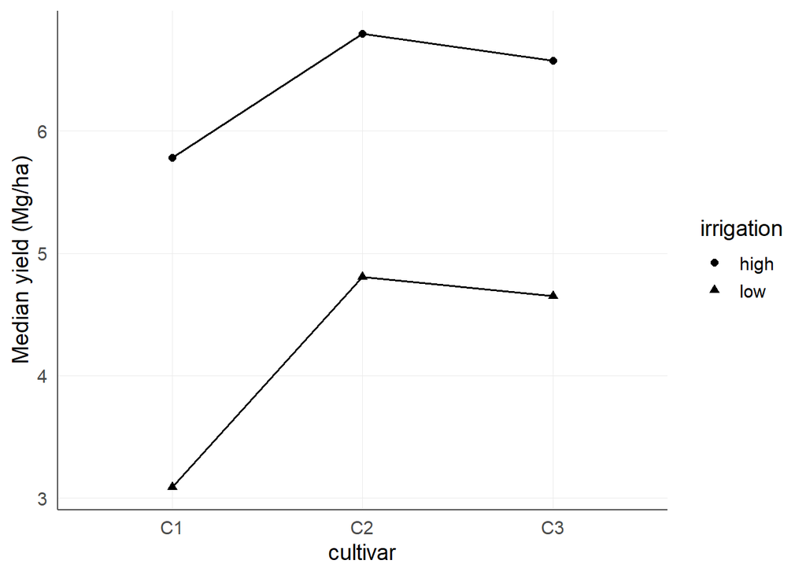

Split-plot: yield by irrigation x cultivar combination.

```r
agri_plot(fit4, type = "interaction") +
  ggplot2::labs(y = "Median yield (Mg/ha)") + agri_theme()
```

```r
# within each cultivar: does irrigation change the yield?
pr4 <- agri_pairs(fit4, by = "cultivar", factor = "irrigation", adjust = "holm")
pr4
```

```
#>   stratum group1 group2 paired_by_block  A cliff_delta hodges_lehmann
#> 1      C1   high    low            TRUE NA          NA       3.469173
#> 2      C2   high    low            TRUE NA          NA       2.619008
#> 3      C3   high    low            TRUE NA          NA       0.849378
#>      p_value p_adjusted
#> 1 0.08005792 0.08005792
#> 2 0.02086258 0.04279856
#> 3 0.01426619 0.04279856
```

**TipHow to read the simple effects**

With two irrigation levels, the simple effects repeat the main effect, and the adjusted individual comparisons are conservative for multifactor ART (the package warns and recommends the ART-C procedure for contrasts). The simple effects pay off with factors of three or more levels, as in the factorial of the previous section. The essential result here is already in the omnibus table: the two main effects act additively.

**TipStudy tip**

Compare the three designs: CRD (no restriction), RCBD (restriction in blocks) and split-plot (two hierarchies). The test changes, the tables change, but the **workflow** is identical: declare the design, fit, omnibus table, effects, letter comparisons and figure. That uniformity is what agriRank offers.

# 3 Part II: Quantitative factor: regression

When the factor is a **dose**, treating it as a qualitative factor wastes the order (0 < 40 < 80 …) and produces an explosion of comparisons. The alternative is regression, but **without imposing a polynomial** without scientific justification. agriRank separates strictly nonparametric smoothers, rank-robust regression and semiparametric models under a single interface.

## 3.1 II.1 Dose-response curve without imposing a shape

**Agronomic question:** how does yield respond to the nitrogen dose, without assuming that the relationship is linear or quadratic?

```r
d_dose <- simulate_agri("dose_response", seed = 11, n = 6)
head(d_dose, 6)
```

```
#>    block dose    yield
#> 1     B1    0 3.240356
#> 7     B1   40 3.223580
#> 13    B1   80 4.004893
#> 19    B1  120 4.602972
#> 25    B1  160 4.642942
#> 31    B1  200 5.070038
```

```r
fit_ss <- agri_np_regression(yield ~ dose, d_dose, method = "smoothing_spline")
fit_ss
```

```
#> agriRank nonparametric regression
#>   Method: smoothing_spline
#>   Response: yield
#>   Predictors: dose
```

```r
agri_table(fit_ss, "metrics", format = "data.frame")
```

```
#>    n      RMSE       MAE     MedAE         bias  Spearman
#> 1 48 0.2905792 0.2388631 0.2100489 3.247402e-15 0.9037675
```

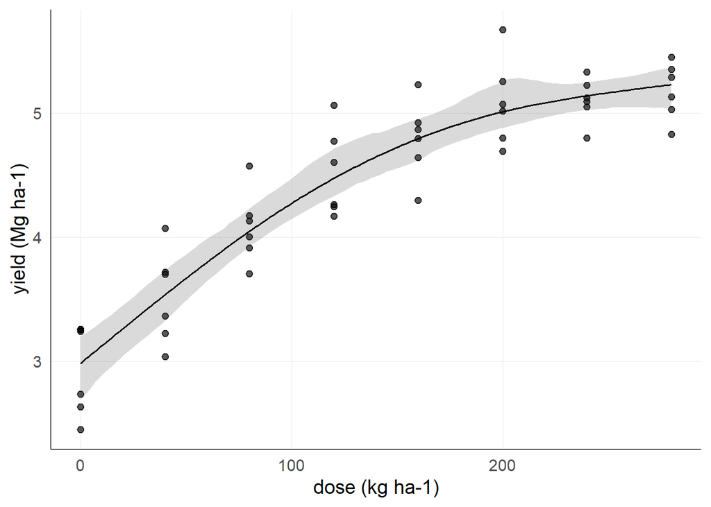

Yield as a function of N dose: observations, smoothed curve and bootstrap band.

```r
# B = 1000 is the inferential value; below that the package emits a warning.
b_ss <- agri_np_bootstrap(fit_ss, B = 1000, n = 80, seed = 12)
agri_np_plot(fit_ss, type = "fit", bootstrap = b_ss,
             x_unit = "kg ha-1", y_unit = "Mg ha-1")
```

**NoteHow to read the figure**

The band covers the curve, not the points: it is the uncertainty of the **mean curve**, not of the individual observation. The plateau above about 200 kg/ha suggests that higher doses do not pay, but that is descriptive; the fertilizer cost decides the economic optimum.

### 3.1.1 Diagnostics and derivative

```r
agri_np_diagnostics(fit_ss, cv = TRUE, kfold = 5, seed = 12)
```

```
#> $method
#> [1] "smoothing_spline"
#>
#> $metrics
#>    n      RMSE       MAE     MedAE         bias  Spearman
#> 1 48 0.2905792 0.2388631 0.2100489 3.247402e-15 0.9037675
#>
#> $r2
#>   pseudo_r2   cv_r2 spearman_r2 effective_df  n
#> 1 0.8757283 0.85515   0.8167956     3.516099 48
#>
#> $residual_median
#> [1] 0.003680994
#>
#> $residual_MAD
#> [1] 0.3168759
#>
#> $residual_fitted_spearman
#> [1] -0.02165892
#>
#> $n_missing_response
#> [1] 0
#>
#> $n_original
#> [1] 48
#>
#> $n_omitted
#> [1] 0
#>
#> $na_action
#> [1] "fail"
#>
#> $details
#> $details$df
#> [1] 3.516099
#>
#> $details$spar
#> [1] 0.4655934
```

```r
agri_np_derivative(fit_ss)
```

```
#>     predictor          x  derivative
#> 1        dose   0.000000 0.013951877
#> 2        dose   1.407035 0.013951310
#> 3        dose   2.814070 0.013949549
#> 4        dose   4.221106 0.013946590
#> 5        dose   5.628141 0.013942434
#> 6        dose   7.035176 0.013937081
#> 7        dose   8.442211 0.013930530
#> 8        dose   9.849246 0.013922782
#> 9        dose  11.256281 0.013913836
#> 10       dose  12.663317 0.013903693
#> 11       dose  14.070352 0.013892353
#> 12       dose  15.477387 0.013879815
#> 13       dose  16.884422 0.013866079
#> 14       dose  18.291457 0.013851147
```

[output cut: 186 more lines]

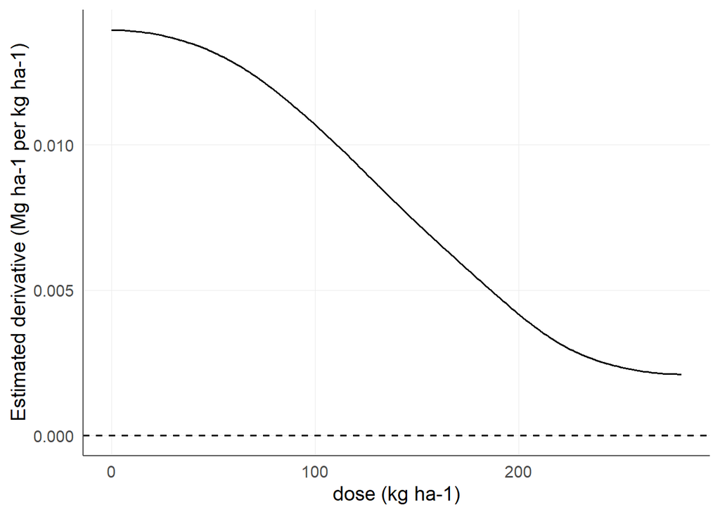

Derivative of the curve: marginal gain per kg/ha of nitrogen.

```r
agri_np_plot(fit_ss, type = "derivative",
             x_unit = "kg ha-1", y_unit = "Mg ha-1 per kg ha-1")
```

```r
agri_np_optimum(fit_ss)
```

```
#>   predictor optimum fitted_response objective at_boundary    support
#> 1      dose     280        5.228808       max        TRUE continuous
```

**WarningCommon mistake**

The returned optimum is **descriptive** (the maximum of the smoothed curve over the observed range), not an economic optimum. An economic optimum requires prices, costs and an objective function declared before the analysis.

## 3.2 II.2 Comparing engines without p-value fishing

```r
agri_np_compare(yield ~ dose, d_dose,
                methods = c("smoothing_spline", "loess"), kfold = 5, seed = 12)
```

```
#>             method  n      RMSE       MAE     MedAE          bias  Spearman
#> 1 smoothing_spline 48 0.3137167 0.2550248 0.2213669  0.0002677379 0.8741210
#> 2            loess 48 0.3243493 0.2692286 0.2426571 -0.0040094455 0.8488093
#>   selected_metric failures
#> 1       0.3137167        0
#> 2       0.3243493        0
```

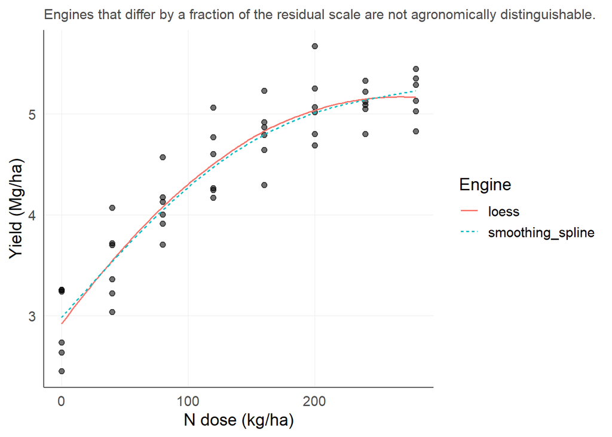

```r
agri_np_curves(yield ~ dose, d_dose, methods = c("smoothing_spline", "loess")) +
  ggplot2::labs(x = "N dose (kg/ha)", y = "Yield (Mg/ha)")
```

**ImportantThe package rule**

`agri_np_compare()` compares **out-of-sample predictive error**: it never uses the p-value to choose the model. The engine is chosen by the **scientific declaration** (expected shape, restriction, family), not by the smallest p.

### 3.2.1 Deterministic automatic selection

```r
f_auto1 <- agri_np_regression(yield ~ dose, d_dose, method = "auto")
f_auto2 <- agri_np_regression(yield ~ dose, d_dose, method = "auto", block = block)
data.frame(
  declaration = c("one numeric predictor, no block", "one numeric predictor, with block"),
  selected_engine = c(f_auto1$method, f_auto2$method)
)
```

```
#>                         declaration  selected_engine
#> 1   one numeric predictor, no block smoothing_spline
#> 2 one numeric predictor, with block              gam
```

With a declared block, `auto` moves to the GAM, which accommodates the block adjustment; the univariate smoother would be rejected for discarding the design.

## 3.3 II.3 From the fit to the publishable figure

```r
dir.create("figuras", showWarnings = FALSE)
dir.create("relatorios", showWarnings = FALSE)

p_final <- agri_np_plot(fit_ss, type = "fit", bootstrap = b_ss,
                        x_unit = "kg ha-1", y_unit = "Mg ha-1") + agri_theme()
agri_save_figure(p_final, "figuras/dose-resposta.png", layout = "column")

rep_path <- agri_report(fit_ss, file = "relatorios/relatorio-dose.md", format = "md")
basename(rep_path)
```

```
#> [1] "relatorio-dose.md"
```

**TipPublication tip**

`agri_save_figure()` writes TIFF/PDF/SVG at journal column widths, and `agri_report()` generates the report with metrics, coefficient table and figures. Because every figure is an editable `ggplot`, nothing is frozen: units, fonts and theme can be changed later.

# 4 Part III: Qualitative + quantitative

**Agronomic question:** do two cultivars respond to the nitrogen dose in different ways, or is the difference between them just a constant shift (same curve, another level)?

## 4.1 III.1 One model with cultivar and dose

```r
dz <- simulate_agri("dose_response", seed = 21, n = 6)
dz$cultivar <- factor(rep(c("Ana", "Bela"), length.out = nrow(dz)))
dz$yield <- dz$yield + ifelse(dz$cultivar == "Bela", 0.8, 0)   # Bela shifts the curve
fit_q <- agri_np_regression(yield ~ dose + cultivar, dz, method = "quantile", block = block)
fit_q
```

```
#> agriRank nonparametric regression
#>   Method: quantile
#>   Response: yield
#>   Predictors: dose, cultivar
#>   Qualitative predictors: cultivar
#>   Note: reference level of cultivar is "Ana". Coefficients are contrasts against the reference.
#>   Block adjustment: block
```

```r
coef(fit_q)
```

```
#>  (Intercept)         dose cultivarBela      blockB2      blockB3      blockB4
#>   3.60830528   0.00796652   0.90529638   0.13320234   0.69687921  -0.29388601
#>      blockB5      blockB6
#>   0.55520044   0.04846464
```

**NoteKey concept: contrast against the reference**

The coefficient `cultivarBela` is the **contrast** of Bela against the reference cultivar (Ana): how much Bela shifts the curve at the same dose. The intercept and the block terms are location/nuisance parameters; the forest below excludes them from the target by default.

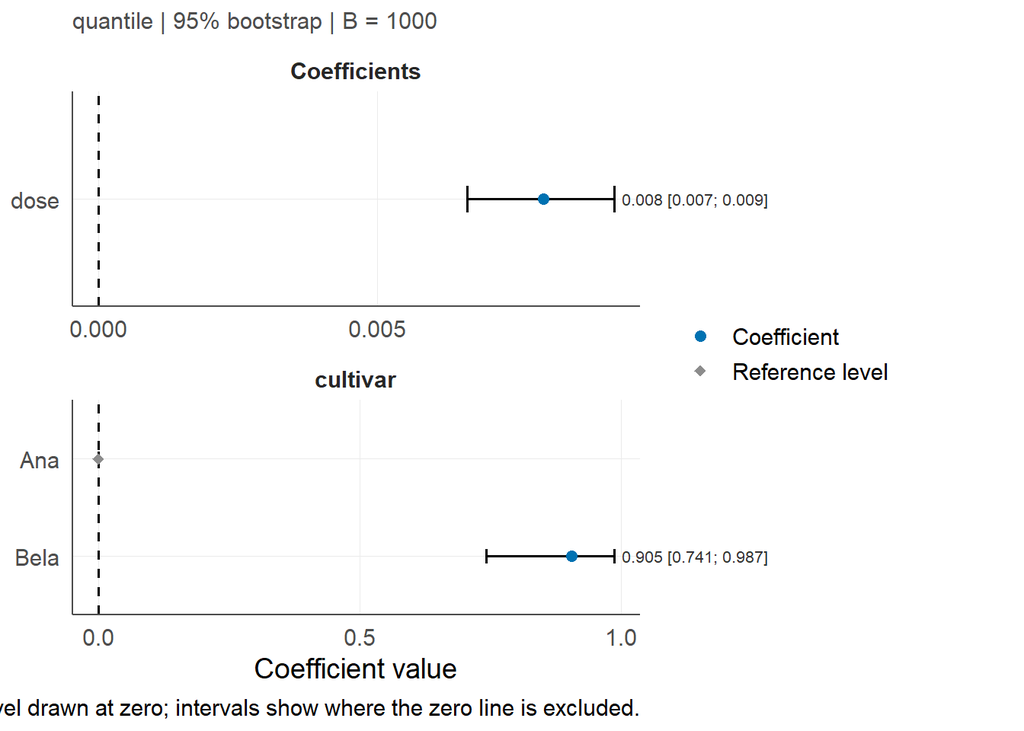

Forest of coefficients: dose slope and cultivar contrast, with bootstrap intervals.

```r
bt <- agri_np_bootstrap(fit_q, target = "coefficients", B = 1000, seed = 22)
agri_np_forest(fit_q, bootstrap = bt, annotate_values = TRUE, digits = 3)
```

## 4.2 III.2 Factor levels with confidence intervals

The forest shows the **contrast**; the manuscript usually wants the response **at each level**:

```r
lv <- agri_np_levels(fit_q, B = 1000, seed = 23)
lv
```

```
#>     factor level  n response_median response_mad response_mean response_sd
#> 1 cultivar   Ana 24        4.902809    1.0859310       4.64725   1.0684945
#> 2 cultivar  Bela 24        5.996744    0.7102409       5.84873   0.7071807
#>        fit    lower    upper
#> 1 4.723618 4.647001 4.750876
#> 2 5.628914 5.470487 5.702029
```

```r
agri_table(fit_q, "levels", B = 1000, seed = 23, format = "data.frame")
```

```
#>     factor level  n response_median response_mad response_mean response_sd
#> 1 cultivar   Ana 24        4.902809    1.0859310       4.64725   1.0684945
#> 2 cultivar  Bela 24        5.996744    0.7102409       5.84873   0.7071807
#>        fit    lower    upper
#> 1 4.723618 4.647001 4.750876
#> 2 5.628914 5.470487 5.702029
```

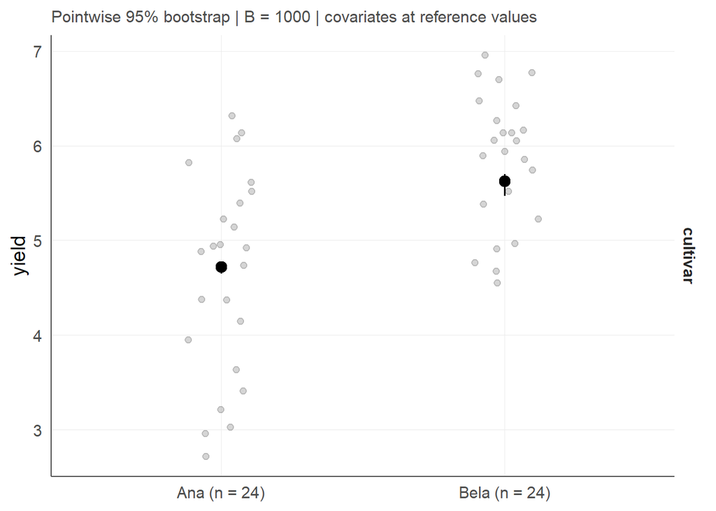

Fitted response in each cultivar, with observations and bootstrap intervals.

```r
agri_np_plot(fit_q, type = "levels", bootstrap = attr(lv, "bootstrap"), y_unit = "Mg ha-1")
```

## 4.3 III.3 Curves per level, with band

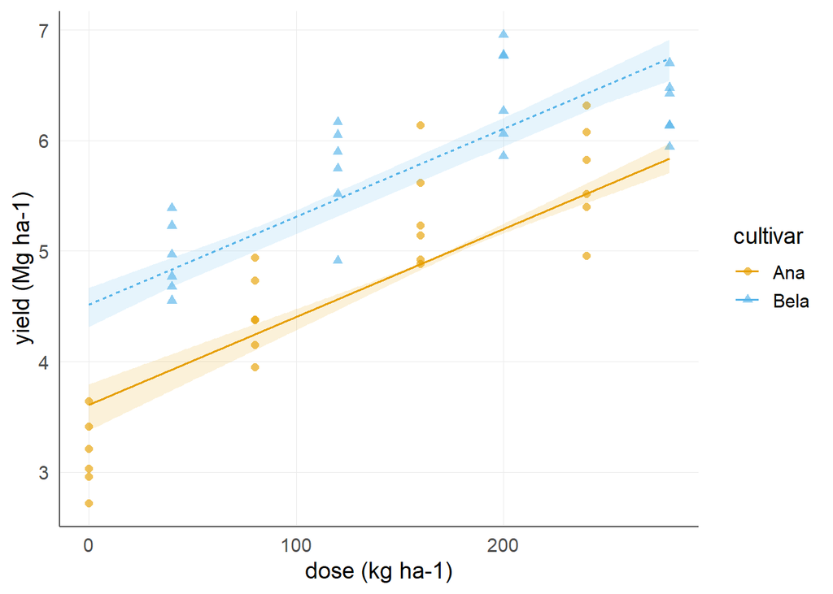

Dose-response curves by cultivar, with a bootstrap band per level (colour-blind palette).

```r
agri_np_plot(fit_q, type = "fit", predictor = "dose", group = "cultivar",
             bootstrap = 1000, seed = 24,
             x_unit = "kg ha-1", y_unit = "Mg ha-1")
```

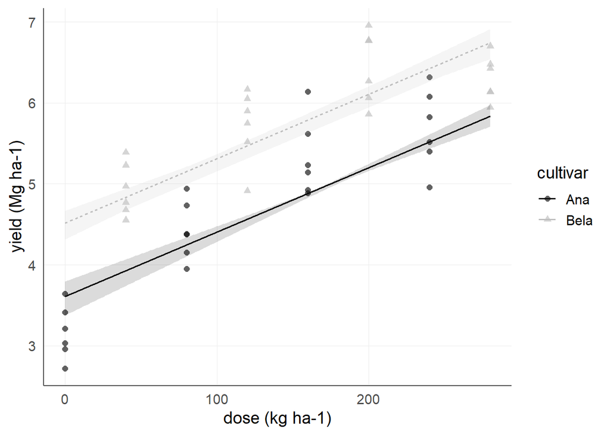

The same figure in the grey palette, for black-and-white print.

```r
agri_np_plot(fit_q, type = "fit", predictor = "dose", group = "cultivar",
             bootstrap = 1000, seed = 24, palette = "grey",
             x_unit = "kg ha-1", y_unit = "Mg ha-1")
```

**TipStudy tip**

The curves are parallel: the model without interaction imposes the same slope on both cultivars, with a fixed shift. If the shift is not reasonable, the next step is a dose by cultivar interaction: declared explicitly, never chosen by the figure.

# 5 Part IV: Integer ordinal factor

## 5.1 IV.1 Why “integer” is different

**Agronomic question:** how many plants per hill maximize the yield? The treatment is integer (1, 2, …, 9 plants): **there is no such thing as 4.37 plants per hill**.

**NoteKey concept: integer decision support**

A continuous model would produce an “optimum” at 5.2 plants/hill: a decision that is impossible in the field. agriRank restricts every fit, prediction and decision to the **admissible integer support** (`predictor_support = "observed_integer"`): only the values actually tested exist.

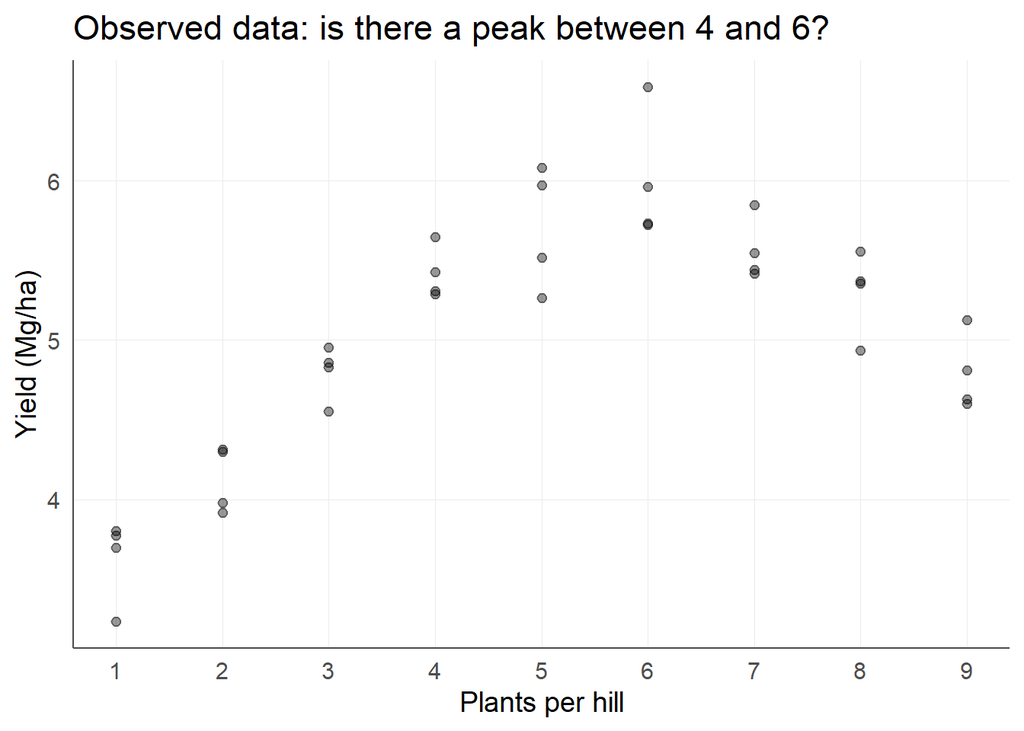

```r
dd <- simulate_agri("integer_density", seed = 31, n = 4)
ggplot2::ggplot(dd, ggplot2::aes(plants, yield)) +
  ggplot2::geom_point(alpha = .4) +
  ggplot2::scale_x_continuous(breaks = unique(dd$plants)) +
  ggplot2::labs(x = "Plants per hill", y = "Yield (Mg/ha)") +
  ggplot2::ggtitle("Observed data: is there a peak between 4 and 6?") + agri_theme()
```

## 5.2 IV.2 Four models for the same support

```r
fit_ig <- agri_np_regression(yield ~ plants, dd, method = "integer_grid",
                             integer_base_method = "smoothing_spline",
                             predictor_support = "observed_integer")
fit_ig
```

```
#> agriRank nonparametric regression
#>   Method: integer_grid
#>   Response: yield
#>   Predictors: plants
#>   Integer decision support: {1, 2, 3, 4, 5, 6, 7, 8, 9}
#>   Latent base method: smoothing_spline
```

```r
agri_integer_predict(fit_ig)
```

```
#>   plants      fit
#> 1      1 3.605964
#> 2      2 4.210046
#> 3      3 4.823821
#> 4      4 5.366839
#> 5      5 5.726035
#> 6      6 5.829201
#> 7      7 5.643623
#> 8      8 5.288078
#> 9      9 4.849377
```

```r
if (requireNamespace("np", quietly = TRUE)) {
  fit_dk <- agri_np_regression(yield ~ plants, dd, method = "discrete_kernel",
                               predictor_support = "observed_integer")
  agri_integer_predict(fit_dk)
}
```

```
#>   plants      fit
#> 1      1 3.718302
#> 2      2 4.181004
#> 3      3 4.796047
#> 4      4 5.365175
#> 5      5 5.674137
#> 6      6 5.896026
#> 7      7 5.565257
#> 8      8 5.297934
#> 9      9 4.870038
```

```r
if (requireNamespace("Iso", quietly = TRUE)) {
  fit_ui <- agri_np_regression(yield ~ plants, dd, method = "unimodal_isotonic",
                               predictor_support = "observed_integer")
  agri_integer_optimum(fit_ui)
}
```

```
#> agriRank integer-support optimum
#>   Objective: max
#>   Admissible support: {1, 2, 3, 4, 5, 6, 7, 8, 9}
#>   Optimal integer value(s): 6
#>   Fitted response: 6.00332
```

```r
if (requireNamespace("cgam", quietly = TRUE)) {
  fit_umb <- agri_np_regression(yield ~ plants, dd, method = "umbrella",
                                predictor_support = "observed_integer")
  agri_integer_optimum(fit_umb)
}
```

```
#> agriRank integer-support optimum
#>   Objective: max
#>   Admissible support: {1, 2, 3, 4, 5, 6, 7, 8, 9}
#>   Optimal integer value(s): 5, 6
#>   Fitted response: 5.85623
```

**NoteThe four integer engines**

- `integer_grid`: a flexible continuous model (here, a spline) **projected** onto the integer support: every decision comes out at admissible values;
- `discrete_kernel`: a kernel for ordered-discrete data (`np`);
- `unimodal_isotonic`: imposes increase-then-decrease without assuming a parametric shape;
- `umbrella`: umbrella-order regression (increases up to a peak and falls).

The figure below places the four engines side by side on the same data. None of them emits a value between two integers: every fit lives on the admissible support.

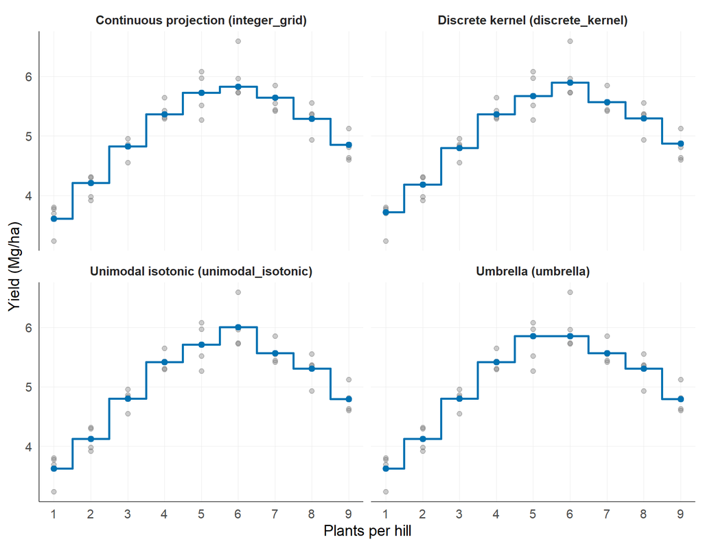

The four integer engines on the same data, all restricted to the admissible support.

```r
modelos <- list(
  "Continuous projection (integer_grid)" = fit_ig,
  "Discrete kernel (discrete_kernel)" = if (exists("fit_dk")) fit_dk else NULL,
  "Unimodal isotonic (unimodal_isotonic)" = if (exists("fit_ui")) fit_ui else NULL,
  "Umbrella (umbrella)" = if (exists("fit_umb")) fit_umb else NULL
)
modelos <- modelos[!vapply(modelos, is.null, logical(1))]

pred <- do.call(rbind, lapply(names(modelos), function(nm) {
  pr <- agri_integer_predict(modelos[[nm]])
  data.frame(modelo = nm, plants = pr[[1]], fit = pr$fit)
}))
pred$modelo <- factor(pred$modelo, levels = names(modelos))

ggplot2::ggplot(dd, ggplot2::aes(plants, yield)) +
  ggplot2::geom_point(alpha = .35, colour = "grey45") +
  ggplot2::geom_step(data = pred, ggplot2::aes(plants, fit),
                     direction = "mid", colour = "#0072B2", linewidth = 1) +
  ggplot2::geom_point(data = pred, ggplot2::aes(plants, fit),
                      colour = "#0072B2", size = 2.2) +
  ggplot2::facet_wrap(~ modelo) +
  ggplot2::scale_x_continuous(breaks = unique(dd$plants)) +
  ggplot2::labs(x = "Plants per hill", y = "Yield (Mg/ha)") +
  agri_theme()
```

**TipHow to read the comparison**

The four engines agree on the peak (between 5 and 7 plants/hill), but differ in the details: the discrete kernel smooths more, the unimodal isotonic delivers pure steps, the continuous projection keeps the spline curvature, and the umbrella explicitly imposes increase-then-decrease. Agreement among engines **from different families** is the best evidence that the peak is not an artifact of a single method; disagreement would send the analyst back to the diagnostics, as the metrics table below would show.

### 5.2.1 Fit quality: R-squared, RMSE, MAE and MAD

No figure replaces numbers. For each engine, agriRank computes the predictive error (RMSE, MAE, median absolute error and MAD of the residuals) and three indices of explained variation, analogous to the R-squared: the **pseudo R-squared** (on the fitted values, which rewards flexibility), the **Spearman R-squared** (rank-based, coherent with the package philosophy) and the **CV R-squared** (out of sample: the honest index for comparing engines).

```r
metr <- do.call(rbind, lapply(names(modelos), function(nm) {
  dg <- agri_np_diagnostics(modelos[[nm]], cv = TRUE, kfold = 5, seed = 33)
  data.frame(Model = nm,
             RMSE = dg$metrics$RMSE,
             MAE = dg$metrics$MAE,
             MedAE = dg$metrics$MedAE,
             MAD_res = dg$residual_MAD,
             R2_pseudo = dg$r2$pseudo_r2,
             R2_spearman = dg$r2$spearman_r2,
             R2_cv = dg$r2$cv_r2)
}))
knitr::kable(metr, digits = 3,
             col.names = c("Model", "RMSE (Mg/ha)", "MAE", "MedAE",
                           "MAD res.", "pseudo R2", "Spearman R2", "CV R2"))
```

Fit quality of the four integer engines. RMSE, MAE, MedAE and MAD in Mg/ha.

| Model | RMSE (Mg/ha) | MAE | MedAE | MAD res. | pseudo R2 | Spearman R2 | CV R2 |
| --- | --- | --- | --- | --- | --- | --- | --- |
| Continuous projection (integer_grid) | 0.245 | 0.198 | 0.199 | 0.265 | 0.898 | 0.855 | 0.854 |
| Discrete kernel (discrete_kernel) | 0.241 | 0.190 | 0.158 | 0.239 | 0.902 | 0.855 | 0.835 |
| Unimodal isotonic (unimodal_isotonic) | 0.233 | 0.193 | 0.173 | 0.249 | 0.908 | 0.859 | 0.841 |
| Umbrella (umbrella) | 0.243 | 0.191 | 0.152 | 0.232 | 0.900 | 0.850 | 0.838 |

**ImportantHow to read the table**

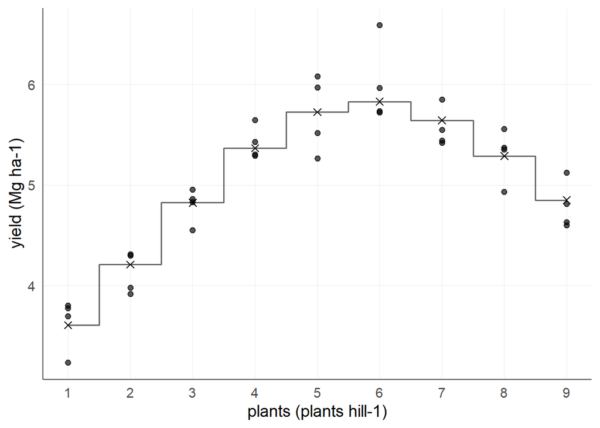

Integer fit drawn as steps: no value exists between two admissible integers.

```r
agri_np_plot(fit_ig, type = "fit", x_unit = "plants hill-1", y_unit = "Mg ha-1")
```

## 5.3 IV.3 Decisions on the integer support

```r
agri_integer_optimum(fit_ig)
```

```
#> agriRank integer-support optimum
#>   Objective: max
#>   Admissible support: {1, 2, 3, 4, 5, 6, 7, 8, 9}
#>   Optimal integer value(s): 6
#>   Fitted response: 5.8292
```

```r
agri_integer_difference(fit_ig, order = 1)          # gain from k to k+1 plants
```

```
#>   from to delta_x fit_from   fit_to difference difference_per_integer
#> 1    1  2       1 3.605964 4.210046  0.6040819              0.6040819
#> 2    2  3       1 4.210046 4.823821  0.6137758              0.6137758
#> 3    3  4       1 4.823821 5.366839  0.5430174              0.5430174
#> 4    4  5       1 5.366839 5.726035  0.3591961              0.3591961
#> 5    5  6       1 5.726035 5.829201  0.1031662              0.1031662
#> 6    6  7       1 5.829201 5.643623 -0.1855781             -0.1855781
#> 7    7  8       1 5.643623 5.288078 -0.3555446             -0.3555446
#> 8    8  9       1 5.288078 4.849377 -0.4387011             -0.4387011
```

```r
agri_integer_threshold(fit_ig, criterion = "fraction_of_maximum", value = 0.95)
```

```
#>             criterion target integer_value fitted_response threshold_response
#> 1 fraction_of_maximum   0.95             5        5.726035           5.537741
```

```r
agri_integer_threshold(fit_ig, criterion = "gain_from_baseline", value = 0.5, baseline = 1)
```

```
#>            criterion target baseline integer_value fitted_response
#> 1 gain_from_baseline    0.5        1             2        4.210046
#>   achieved_gain
#> 1     0.6040819
```

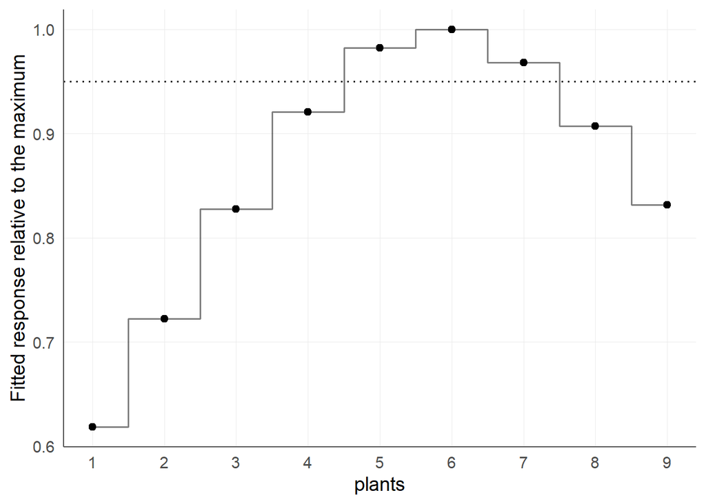

Efficiency relative to the fitted maximum at each density.

```r
agri_np_plot(fit_ig, type = "efficiency")
```

**WarningCommon mistake**

“Never round a continuous optimum to an integer”: agriRank does not even allow it, because the optimum is **searched on the integer support** from the fit itself. A threshold such as “95% of the maximum” returns the smallest integer density that already meets the criterion, ready to become a recommendation.

## 5.4 IV.4 The uncertainty of the integer optimum

```r
bi <- agri_integer_bootstrap(fit_ig, B = 1000, seed = 32)   # resamples and re-optimizes
bi
```

```
#> agriRank bootstrap distribution of the integer optimum
#>   Objective: max
#>   Successful refits: 1000 / 1000
#>  plants probability
#>       1       0.000
#>       2       0.000
#>       3       0.000
#>       4       0.000
#>       5       0.067
#>       6       0.929
#>       7       0.004
#>       8       0.000
#>       9       0.000
```

```r
cs <- agri_integer_confset(bi, level = 0.9)
cs
```

```
#> agriRank bootstrap confidence set for an integer optimum
#>   Level: 90%
#>   Set: {6}
#>   Included bootstrap mass: 0.929
```

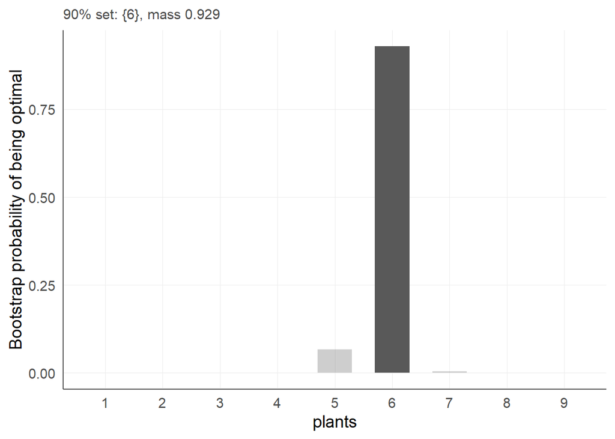

Bootstrap distribution of the optimum and the 90% confidence set.

```r
plot(cs)
```

**TipHow to read the confidence set**

Each resample elects one optimum; the table above is the frequency with which each density won in 1000 refits (the probabilities sum to 100%). Instead of “the optimum is 6 plants/hill”, the honest answer is: the density(ies) 6 concentrate(s) 93% of the probability of being optimal, forming the confidence set at 90%. It is a **set of admissible decisions**, not a continuous interval that would suggest fractions of a plant.

# 6 Closing

## 6.1 The complete workflow in one figure

[output not shown]

[output not shown]

## 6.2 Good practices

**ImportantThe four rules of this tutorial**

1. **Declare before analysing**: design, expected shape and restrictions come from science, not from the p-value;
2. **`B = 1000` in every resampling**: below 999 the package warns that it is only a speed device; for final work, consider larger values;
3. **Letters and intervals have strata**: never compare what was not compared;
4. **Figure is ggplot, table is data.frame**: everything remains editable up to submission.

## 6.3 Exercises

**CautionExercise 1: Identify (level 1)**

A researcher draws 5 cultivars in a nursery with 4 benches; each bench receives all cultivars once. Which design? Which function declares it? Which test does `method = "auto"` select?

**Solution:** RCBD (the benches are blocks). `agri_design(yield ~ cultivar, data, design = "rcbd", block = bench)`; with one factor and a block, the automatic method selects Friedman.

**CautionExercise 2: Apply (level 2)**

Generate `simulate_agri("crd", seed = 7)`, rename the treatments as you like and reproduce the complete CRD workflow: declaration, analysis, letters and effects figure.

**Solution:** the code of Section 2.1 with another seed; the interpretation of the letters is the only step that changes.

**CautionExercise 3: Interpret (level 3)**

In the factorial of Section 2.3, suppose the simple effects show: within N3, G1 and G2 differ; within N1 and N2 they do not. How would you write this in a paper, and what CANNOT be concluded?

**Solution:** “The genotype effect appeared only at the highest fertilization (N3; adjusted p < 0.05)”. One cannot conclude that the genotypes are equal in N1/N2: only that there was no evidence of a difference at 5% (absence of evidence is not evidence of absence).

**CautionExercise 4: Create (level 4)**

Your own experiment: 3 maize hybrids under 4 planting densities (integer), in 4 blocks. Describe the design, the two agriRank modules you would use and the sequence of decisions up to the final recommendation.

**Solution (sketch):** split-plot (density at the whole-plot, hybrid at the subplot) for the qualitative part; for the integer part, `agri_np_regression(..., method = "integer_grid", predictor_support = "integer_range")` followed by `agri_integer_optimum`, `agri_integer_threshold` and `agri_integer_bootstrap` to report the confidence set of the optimum. The recommendation combines the hybrid effect (letters/effects) with the density optimum (integer), without rounding continuous optima.

## 6.4 How to cite

```r
citation("agriRank")
```

[output not shown]

```r
packageVersion("agriRank")
```

```
#> [1] '0.13.0'
```

```r
R.version.string
```

```
#> [1] "R version 4.6.0 (2026-04-24 ucrt)"
```

Include the citation above in the reference list and state the R and package versions in the Material and Methods section.